# H06 daily metrics — complete Stage 2 production

Complementary preregistration-oriented participant-day evidence and H06-D-G2 author gate

Published

August 12, 2026

# 1 Stage 2 verdict

**ImportantH06-D-G2 status — author review required**

The authorized production grid is complete: **468** non-L10 metric × predictor × scenario cells, **936** raw omnibus tests, **66,664** participant/site deletion refits, and **12 complete named 15-slot Benjamini–Hochberg (BH) families**. L10 mean remains the frozen named non-estimable slot 3; MDER raw results remain frozen in slot 15, with only its mathematically dependent BH fields recalculated.

Of the 39 primary near-eye non-L10 cells, 4 are acceptable, 4 are acceptable only with an explicit limitation, and 31 do not support an unqualified association claim under the prespecified rules. The individual estimates and complete multiplicity vectors remain visible below so numerical results are not selected after diagnostics.

This document is the mandatory Stage 2 stop. It does **not** authorize the compact Stage 3 reader report, the separate Stage 4 provenance companion, website integration, or any change to the selected hourly main H06 analysis.

# 2 Scientific target and analysis roles

The daily variant asks how recorded day-level contexts are associated with participant-day light-exposure metrics. Each admissible metric-specific day contributes exactly one row. It neither models repeated hourly melEDI nor weights days by the number of supported hours. Under `H06-007`, the completed hourly H06 analysis remains the main analysis; this daily analysis is complementary evidence closer to the registered daily-metric outcome wording.

Table 1: Scientific and reporting roles retained in Stage 2.

| Component | Role | What it estimates | Inferential use |
| --- | --- | --- | --- |
| Primary near eye, all available | Primary daily-metric route | Equal-site association and site heterogeneity on each metric-specific day frame | Supplies the primary raw slots and primary BH families |
| Chest, all available | Contextual complement | The same metric/context association at the chest placement | Estimate and pointwise 95% CI only |
| Paired/common near eye and chest | Placement complement | Near-eye/chest comparison on common participant-days | Estimate and pointwise 95% CI only |
| Gap-timing-unaware near eye | Dataset sensitivity | The same association after ignoring gap timing during metric construction | Separate 15-slot BH families |
| Dataset-common primary/gap frames | Sample-controlled dataset comparison | Primary versus gap handling on the same participant-days | Estimate and pointwise 95% CI only |

All statements concern observational associations with recorded day-level contexts. No causal or health-outcome claim is made.

# 3 Exact production implementation

## 3.1 Model routes

The nine non-timing outcomes retain the approved fixed-site mixed-model hierarchy, with a participant random intercept:

```r
response_value ~ site + (1 | participant_key)
response_value ~ site + predictor + (1 | participant_key)
response_value ~ site * predictor + (1 | participant_key)
```

Gaussian comparisons use maximum likelihood and estimates use REML. Tweedie models use a log link. The registered random-site/random-slope formula remains a visible benchmark and never replaces the fixed-site primary hierarchy.

The four repaired timing outcomes use the uniformly accepted fixed-site linear hierarchy:

```r
response_value ~ site
response_value ~ site + predictor
response_value ~ site * predictor
```

Their covariance is participant-cluster HC3 from `sandwich::vcovCL(type = "HC3", cadjust = TRUE, fix = FALSE)`, with participant-cluster-minus-one t/F references and **pointwise** 95% confidence intervals. No simultaneous interval is used.

Site uses sum-to-zero coding throughout. Categorical effects are Free day minus Work day and Active minus Sedentary. Sleep duration is the per-hour association for a previous-night duration centered at 8 h. Because this daily model does not include separate participant-mean and day-deviation sleep terms, that coefficient combines between-participant and within-participant comparisons; the participant random intercept does not by itself separate them. Equal-site marginalization is used rather than weighting sites by their number of observations.

## 3.2 Exact fitted samples

Table 2: Exact primary near-eye fitted samples for the 39 non-L10 cells.

| Slot | Metric | Participant-days | Participants | Sites | Exact zeros |
| --- | --- | --- | --- | --- | --- |
| Previous-night sleep duration |  |  |  |  |  |
| 1 | Mean melEDI | 784 | 141 | 9 | 0 |
| 2 | Brightest 10 h mean | 784 | 141 | 9 | 0 |
| 4 | Time above 1,000 lx melEDI | 784 | 141 | 9 | 94 |
| 5 | Time above 250 lx melEDI during wake | 729 | 141 | 9 | 25 |
| 6 | Time below 10 lx melEDI before sleep | 648 | 139 | 9 | 10 |
| 7 | Time below 1 lx melEDI during sleep | 770 | 141 | 9 | 4 |
| 8 | Longest continuous period above 250 lx melEDI | 784 | 141 | 9 | 26 |
| 9 | Midpoint of the brightest 10 hours | 784 | 141 | 9 | 0 |
| 10 | Midpoint of the darkest 10 hours | 784 | 141 | 9 | 0 |
| 11 | Mean timing of exposure above 250 lx melEDI | 715 | 141 | 9 | 0 |
| 12 | First light timing above 250 lx melEDI | 701 | 140 | 9 | 1 |
| 13 | Last light timing above 250 lx melEDI | 661 | 141 | 9 | 0 |
| 14 | melEDI dose | 729 | 141 | 9 | 0 |
| Daily activity status |  |  |  |  |  |
| 1 | Mean melEDI | 734 | 137 | 9 | 0 |
| 2 | Brightest 10 h mean | 734 | 137 | 9 | 0 |
| 4 | Time above 1,000 lx melEDI | 734 | 137 | 9 | 85 |
| 5 | Time above 250 lx melEDI during wake | 675 | 136 | 9 | 19 |
| 6 | Time below 10 lx melEDI before sleep | 602 | 134 | 9 | 10 |
| 7 | Time below 1 lx melEDI during sleep | 713 | 136 | 9 | 4 |
| 8 | Longest continuous period above 250 lx melEDI | 734 | 137 | 9 | 21 |
| 9 | Midpoint of the brightest 10 hours | 734 | 137 | 9 | 0 |
| 10 | Midpoint of the darkest 10 hours | 734 | 137 | 9 | 0 |
| 11 | Mean timing of exposure above 250 lx melEDI | 676 | 137 | 9 | 0 |
| 12 | First light timing above 250 lx melEDI | 658 | 136 | 9 | 1 |
| 13 | Last light timing above 250 lx melEDI | 626 | 137 | 9 | 0 |
| 14 | melEDI dose | 686 | 137 | 9 | 0 |
| Work/free day |  |  |  |  |  |
| 1 | Mean melEDI | 784 | 141 | 9 | 0 |
| 2 | Brightest 10 h mean | 784 | 141 | 9 | 0 |
| 4 | Time above 1,000 lx melEDI | 784 | 141 | 9 | 94 |
| 5 | Time above 250 lx melEDI during wake | 729 | 141 | 9 | 25 |
| 6 | Time below 10 lx melEDI before sleep | 648 | 139 | 9 | 10 |
| 7 | Time below 1 lx melEDI during sleep | 770 | 141 | 9 | 4 |
| 8 | Longest continuous period above 250 lx melEDI | 784 | 141 | 9 | 26 |
| 9 | Midpoint of the brightest 10 hours | 784 | 141 | 9 | 0 |
| 10 | Midpoint of the darkest 10 hours | 784 | 141 | 9 | 0 |
| 11 | Mean timing of exposure above 250 lx melEDI | 715 | 141 | 9 | 0 |
| 12 | First light timing above 250 lx melEDI | 701 | 140 | 9 | 1 |
| 13 | Last light timing above 250 lx melEDI | 661 | 141 | 9 | 0 |
| 14 | melEDI dose | 729 | 141 | 9 | 0 |

Every row is one exact fitted frame. Exact zeros are retained under the approved outcome-specific response family.

# 4 Primary near-eye estimates

The two figures show adjusted effects and pointwise 95% confidence intervals. Ratios refer to the fitted response scale stated in the source table—for shifted-log outcomes, the ratio is for the fitted metric plus 0.1, not a raw metric ratio. Absolute timing and duration effects are shown in hours.

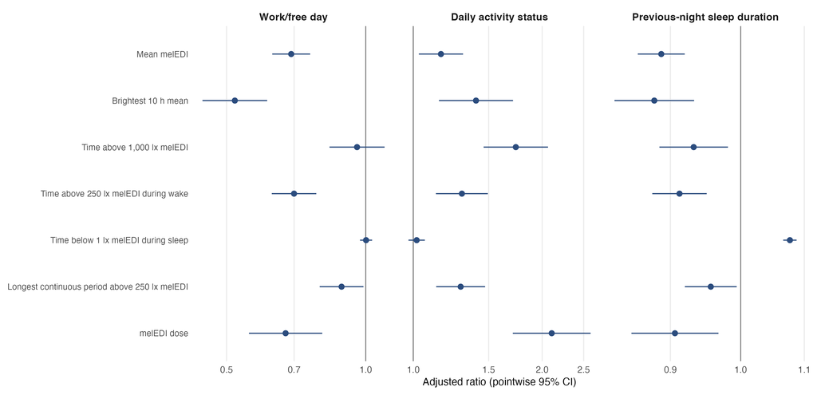

Figure 1: Adjusted multiplicative associations for the seven ratio-scale non-L10 daily metrics. Each row shows a point estimate and pointwise 95% confidence interval; the vertical reference at one denotes no association. Panels show Work versus Free day, Active versus Sedentary, and each additional hour of previous-night sleep.

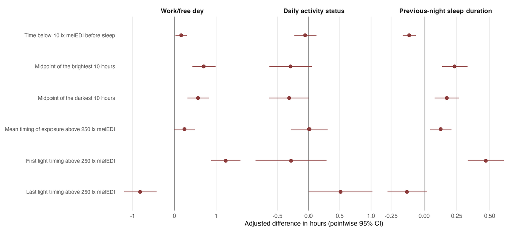

Figure 2: Adjusted absolute associations for six duration or timing outcomes. Each row shows a point estimate and pointwise 95% confidence interval; the vertical reference at zero denotes no association.

The paired source-data CSVs are sealed with the figures. The tables below give the exact samples, p-values, BH values, and diagnostic claim status behind the plots.

**Work/free day**

Table 3: Primary near-eye associations with Work versus Free day.

| Slot | Metric | Participant-days | Effect | Raw p | BH q | Assessment |
| --- | --- | --- | --- | --- | --- | --- |
| 1 | Mean melEDI | 784 | 0.690 (0.628 to 0.758) | <0.001 | <0.001 | Not acceptable |
| 2 | Brightest 10 h mean | 784 | 0.521 (0.444 to 0.612) | <0.001 | <0.001 | Not acceptable |
| 4 | Time above 1,000 lx melEDI | 784 | 0.958 (0.835 to 1.098) | 0.536 | 0.669 | Not acceptable |
| 5 | Time above 250 lx melEDI during wake | 729 | 0.700 (0.626 to 0.782) | <0.001 | <0.001 | Not acceptable |
| 6 | Time below 10 lx melEDI before sleep | 648 | 0.17 (0.03 to 0.30) | 0.018 | 0.030 | Not acceptable |
| 7 | Time below 1 lx melEDI during sleep | 770 | 1.002 (0.972 to 1.032) | 0.920 | 0.986 | Not acceptable |
| 8 | Longest continuous period above 250 lx melEDI | 784 | 0.887 (0.795 to 0.989) | 0.029 | 0.044 | Not acceptable |
| 9 | Midpoint of the brightest 10 hours | 784 | 0.71 (0.44 to 0.99) | <0.001 | <0.001 | Not acceptable |
| 10 | Midpoint of the darkest 10 hours | 784 | 0.57 (0.32 to 0.83) | <0.001 | <0.001 | Not acceptable |
| 11 | Mean timing of exposure above 250 lx melEDI | 715 | 0.24 (-0.01 to 0.50) | 0.060 | 0.081 | Acceptable |
| 12 | First light timing above 250 lx melEDI | 701 | 1.23 (0.87 to 1.59) | <0.001 | <0.001 | Not acceptable |
| 13 | Last light timing above 250 lx melEDI | 661 | -0.82 (-1.21 to -0.43) | <0.001 | <0.001 | Not acceptable |
| 14 | melEDI dose | 729 | 0.671 (0.559 to 0.805) | <0.001 | <0.001 | Acceptable with limitation |

Effect is estimate (pointwise 95% CI). BH uses the complete primary Work/free-day 15-slot association family; slot 3 is retained as NA.

**Activity status**

Table 4: Primary near-eye associations with Active versus Sedentary days.

| Slot | Metric | Participant-days | Effect | Raw p | BH q | Assessment |
| --- | --- | --- | --- | --- | --- | --- |
| 1 | Mean melEDI | 734 | 1.161 (1.030 to 1.307) | 0.014 | 0.035 | Not acceptable |
| 2 | Brightest 10 h mean | 734 | 1.401 (1.148 to 1.710) | <0.001 | 0.003 | Not acceptable |
| 4 | Time above 1,000 lx melEDI | 734 | 1.736 (1.460 to 2.064) | <0.001 | <0.001 | Not acceptable |
| 5 | Time above 250 lx melEDI during wake | 675 | 1.299 (1.130 to 1.493) | <0.001 | <0.001 | Not acceptable |
| 6 | Time below 10 lx melEDI before sleep | 602 | -0.05 (-0.23 to 0.12) | 0.586 | 0.677 | Not acceptable |
| 7 | Time below 1 lx melEDI during sleep | 713 | 1.018 (0.975 to 1.064) | 0.416 | 0.520 | Acceptable with limitation |
| 8 | Longest continuous period above 250 lx melEDI | 734 | 1.290 (1.131 to 1.472) | <0.001 | <0.001 | Not acceptable |
| 9 | Midpoint of the brightest 10 hours | 734 | -0.29 (-0.63 to 0.05) | 0.097 | 0.162 | Not acceptable |
| 10 | Midpoint of the darkest 10 hours | 734 | -0.31 (-0.63 to 0.01) | 0.060 | 0.113 | Acceptable with limitation |
| 11 | Mean timing of exposure above 250 lx melEDI | 676 | 0.01 (-0.28 to 0.30) | 0.965 | 1.000 | Not acceptable |
| 12 | First light timing above 250 lx melEDI | 658 | -0.28 (-0.85 to 0.29) | 0.330 | 0.450 | Not acceptable |
| 13 | Last light timing above 250 lx melEDI | 626 | 0.51 (0.01 to 1.02) | 0.048 | 0.102 | Not acceptable |
| 14 | melEDI dose | 686 | 2.105 (1.708 to 2.595) | <0.001 | <0.001 | Not acceptable |

Effect is estimate (pointwise 95% CI). BH uses the complete primary activity-status 15-slot association family; slot 3 is retained as NA.

**Previous-night sleep duration**

Table 5: Primary near-eye associations per additional hour of previous-night sleep duration.

| Slot | Metric | Participant-days | Effect | Raw p | BH q | Assessment |
| --- | --- | --- | --- | --- | --- | --- |
| 1 | Mean melEDI | 784 | 0.888 (0.857 to 0.920) | <0.001 | <0.001 | Not acceptable |
| 2 | Brightest 10 h mean | 784 | 0.879 (0.828 to 0.933) | <0.001 | <0.001 | Not acceptable |
| 4 | Time above 1,000 lx melEDI | 784 | 0.932 (0.885 to 0.981) | 0.007 | 0.010 | Not acceptable |
| 5 | Time above 250 lx melEDI during wake | 729 | 0.912 (0.876 to 0.950) | <0.001 | <0.001 | Not acceptable |
| 6 | Time below 10 lx melEDI before sleep | 648 | -0.11 (-0.16 to -0.06) | <0.001 | <0.001 | Acceptable |
| 7 | Time below 1 lx melEDI during sleep | 770 | 1.077 (1.066 to 1.087) | <0.001 | <0.001 | Acceptable with limitation |
| 8 | Longest continuous period above 250 lx melEDI | 784 | 0.956 (0.920 to 0.994) | 0.022 | 0.028 | Not acceptable |
| 9 | Midpoint of the brightest 10 hours | 784 | 0.23 (0.14 to 0.33) | <0.001 | <0.001 | Not acceptable |
| 10 | Midpoint of the darkest 10 hours | 784 | 0.17 (0.08 to 0.27) | <0.001 | <0.001 | Not acceptable |
| 11 | Mean timing of exposure above 250 lx melEDI | 715 | 0.13 (0.04 to 0.21) | 0.003 | 0.004 | Acceptable |
| 12 | First light timing above 250 lx melEDI | 701 | 0.47 (0.33 to 0.61) | <0.001 | <0.001 | Not acceptable |
| 13 | Last light timing above 250 lx melEDI | 661 | -0.13 (-0.28 to 0.02) | 0.092 | 0.106 | Not acceptable |
| 14 | melEDI dose | 729 | 0.906 (0.849 to 0.967) | 0.003 | 0.004 | Acceptable |

Effect is estimate (pointwise 95% CI). BH uses the complete primary sleep-duration 15-slot association family; slot 3 is retained as NA.

# 5 Multiplicity and frozen slots

## 5.1 Twelve complete families

Table 6: Completion and decision counts for all twelve 15-slot BH families.

| Predictor | Test | Family | Named slots | Estimable slots | Raw p<0.05 | BH q<0.05 | BH and diagnostically eligible |
| --- | --- | --- | --- | --- | --- | --- | --- |
| Gap-timing-unaware |  |  |  |  |  |  |  |
| Work/free day | Association | gap_timing_unaware__H06-D-A01 | 15 | 14 | 10 | 10 | 0 |
| Daily activity status | Association | gap_timing_unaware__H06-D-A03 | 15 | 14 | 7 | 6 | 0 |
| Previous-night sleep duration | Association | gap_timing_unaware__H06-D-A11 | 15 | 14 | 13 | 13 | 1 |
| Work/free day | Predictor by site | gap_timing_unaware__H06-D-H01 | 15 | 14 | 8 | 8 | 0 |
| Daily activity status | Predictor by site | gap_timing_unaware__H06-D-H03 | 15 | 14 | 5 | 3 | 0 |
| Previous-night sleep duration | Predictor by site | gap_timing_unaware__H06-D-H11 | 15 | 14 | 3 | 1 | 0 |
| Primary |  |  |  |  |  |  |  |
| Work/free day | Association | primary__H06-D-A01 | 15 | 14 | 10 | 10 | 0 |
| Daily activity status | Association | primary__H06-D-A03 | 15 | 14 | 7 | 6 | 0 |
| Previous-night sleep duration | Association | primary__H06-D-A11 | 15 | 14 | 12 | 12 | 3 |
| Work/free day | Predictor by site | primary__H06-D-H01 | 15 | 14 | 8 | 8 | 0 |
| Daily activity status | Predictor by site | primary__H06-D-H03 | 15 | 14 | 4 | 2 | 0 |
| Previous-night sleep duration | Predictor by site | primary__H06-D-H11 | 15 | 14 | 3 | 1 | 0 |

Each vector retains all 15 named slots. Slot 3 is the frozen L10 NA; slot 15 uses the frozen MDER raw test. Diagnostics govern claim eligibility but do not remove a numerically estimable prespecified raw test.

## 5.2 L10 and MDER dispositions

L10 mean melEDI remains `NON_ESTIMABLE_COMPONENT_FAILURE` in all 12 joint slots; its raw and adjusted p-values are missing. Positive-only and MAP results remain descriptive historical diagnostics and are not substituted. MDER uses the approved arithmetic mean of viable positive finite one-minute melEDI/illuminance ratios. Its raw model results are frozen; only family-wide adjusted fields change when the 15-slot vectors are completed.

Table 7: Primary association-family status for frozen slots 3 and 15.

| Predictor | Slot | Metric | Slot status | Raw p | BH q | Adjusted decision |
| --- | --- | --- | --- | --- | --- | --- |
| Work/free day | 3 | Darkest 10 h mean | FROZEN_NAMED_NA_L10_COMPONENT_FAILURE | — | — | NOT_ESTIMABLE |
| Work/free day | 15 | Melanopic daylight efficacy ratio | FROZEN_MDER_RAW_RESULT | 0.830 | 0.958 | BH_Q_GE_0.05 |
| Daily activity status | 3 | Darkest 10 h mean | FROZEN_NAMED_NA_L10_COMPONENT_FAILURE | — | — | NOT_ESTIMABLE |
| Daily activity status | 15 | Melanopic daylight efficacy ratio | FROZEN_MDER_RAW_RESULT | 0.275 | 0.413 | BH_Q_GE_0.05 |
| Previous-night sleep duration | 3 | Darkest 10 h mean | FROZEN_NAMED_NA_L10_COMPONENT_FAILURE | — | — | NOT_ESTIMABLE |
| Previous-night sleep duration | 15 | Melanopic daylight efficacy ratio | FROZEN_MDER_RAW_RESULT | 0.483 | 0.517 | BH_Q_GE_0.05 |

No L10 or MDER model, estimate, interval, diagnostic, sensitivity, or raw p-value was refitted or changed in this production run.

The selected-candidate MDER point estimates and pointwise 95% intervals are retained below for context; they remain the sealed METRIC-010 results.

Table 8: Frozen primary near-eye MDER effect estimates.

| Predictor | Contrast | Participant-days | Participants | MDER difference (95% CI) |
| --- | --- | --- | --- | --- |
| Work/free day | Free day minus Work day | 679 | 136 | -0.001 (-0.013 to 0.011) |
| Daily activity status | Active minus Sedentary | 645 | 133 | 0.008 (-0.007 to 0.024) |
| Previous-night sleep duration | Per 1 h greater previous-night sleep duration | 679 | 136 | 0.002 (-0.003 to 0.006) |

Absolute MDER differences from the frozen Gaussian selected candidate. Student-t sensitivities remain stored separately.

# 6 Complementary placement evidence

The placement comparisons below use the same approved model route within each metric. They are estimation-only: no additional p-value screen is created.

Table 9: Primary-dataset near-eye, chest, and paired/common point estimates.

| Metric | Near eye, all available | Chest, all available | Near eye, paired/common | Chest, paired/common |
| --- | --- | --- | --- | --- |
| Previous-night sleep duration |  |  |  |  |
| Mean melEDI | 0.888 (0.857 to 0.920); n=784 days/141 participants | 0.855 (0.824 to 0.888); n=870 days/154 participants | 0.870 (0.835 to 0.908); n=614 days/112 participants | 0.860 (0.822 to 0.900); n=614 days/112 participants |
| Brightest 10 h mean | 0.879 (0.828 to 0.933); n=784 days/141 participants | 0.827 (0.777 to 0.881); n=870 days/154 participants | 0.845 (0.789 to 0.906); n=614 days/112 participants | 0.830 (0.770 to 0.894); n=614 days/112 participants |
| Time above 1,000 lx melEDI | 0.932 (0.885 to 0.981); n=784 days/141 participants | 0.919 (0.877 to 0.963); n=870 days/154 participants | 0.909 (0.858 to 0.962); n=614 days/112 participants | 0.905 (0.856 to 0.958); n=614 days/112 participants |
| Time above 250 lx melEDI during wake | 0.912 (0.876 to 0.950); n=729 days/141 participants | 0.892 (0.859 to 0.926); n=811 days/154 participants | 0.885 (0.847 to 0.924); n=571 days/112 participants | 0.884 (0.846 to 0.924); n=571 days/112 participants |
| Time below 10 lx melEDI before sleep | -0.11 (-0.16 to -0.06); n=648 days/139 participants | -0.12 (-0.17 to -0.07); n=737 days/153 participants | -0.11 (-0.17 to -0.06); n=499 days/110 participants | -0.12 (-0.18 to -0.07); n=499 days/110 participants |
| Time below 1 lx melEDI during sleep | 1.077 (1.066 to 1.087); n=770 days/141 participants | 1.082 (1.072 to 1.092); n=854 days/154 participants | 1.077 (1.065 to 1.089); n=601 days/112 participants | 1.086 (1.073 to 1.099); n=601 days/112 participants |
| Longest continuous period above 250 lx melEDI | 0.956 (0.920 to 0.994); n=784 days/141 participants | 0.932 (0.899 to 0.966); n=870 days/154 participants | 0.934 (0.895 to 0.975); n=614 days/112 participants | 0.930 (0.892 to 0.970); n=614 days/112 participants |
| Midpoint of the brightest 10 hours | 0.23 (0.14 to 0.33); n=784 days/141 participants | 0.23 (0.14 to 0.33); n=870 days/154 participants | 0.26 (0.15 to 0.36); n=614 days/112 participants | 0.26 (0.15 to 0.36); n=614 days/112 participants |
| Midpoint of the darkest 10 hours | 0.17 (0.08 to 0.27); n=784 days/141 participants | 0.17 (0.08 to 0.26); n=870 days/154 participants | 0.17 (0.06 to 0.28); n=614 days/112 participants | 0.16 (0.05 to 0.26); n=614 days/112 participants |
| Mean timing of exposure above 250 lx melEDI | 0.13 (0.04 to 0.21); n=715 days/141 participants | 0.15 (0.07 to 0.23); n=805 days/154 participants | 0.16 (0.06 to 0.25); n=550 days/112 participants | 0.22 (0.13 to 0.31); n=550 days/112 participants |
| First light timing above 250 lx melEDI | 0.47 (0.33 to 0.61); n=701 days/140 participants | 0.45 (0.30 to 0.61); n=776 days/154 participants | 0.47 (0.32 to 0.62); n=541 days/112 participants | 0.53 (0.37 to 0.69); n=541 days/112 participants |
| Last light timing above 250 lx melEDI | -0.13 (-0.28 to 0.02); n=661 days/141 participants | -0.18 (-0.30 to -0.06); n=761 days/154 participants | -0.19 (-0.36 to -0.03); n=502 days/112 participants | -0.16 (-0.30 to -0.02); n=502 days/112 participants |
| melEDI dose | 0.906 (0.849 to 0.967); n=729 days/141 participants | 0.858 (0.805 to 0.915); n=820 days/154 participants | 0.871 (0.810 to 0.937); n=569 days/112 participants | 0.842 (0.778 to 0.911); n=569 days/112 participants |
| Daily activity status |  |  |  |  |
| Mean melEDI | 1.161 (1.030 to 1.307); n=734 days/137 participants | 1.149 (1.014 to 1.302); n=810 days/149 participants | 1.144 (0.992 to 1.320); n=571 days/109 participants | 1.117 (0.953 to 1.308); n=571 days/109 participants |
| Brightest 10 h mean | 1.401 (1.148 to 1.710); n=734 days/137 participants | 1.432 (1.166 to 1.758); n=810 days/149 participants | 1.354 (1.072 to 1.710); n=571 days/109 participants | 1.377 (1.062 to 1.785); n=571 days/109 participants |
| Time above 1,000 lx melEDI | 1.736 (1.460 to 2.064); n=734 days/137 participants | 1.583 (1.366 to 1.835); n=810 days/149 participants | 1.753 (1.448 to 2.122); n=571 days/109 participants | 1.575 (1.309 to 1.896); n=571 days/109 participants |
| Time above 250 lx melEDI during wake | 1.299 (1.130 to 1.493); n=675 days/136 participants | 1.294 (1.145 to 1.461); n=741 days/148 participants | 1.196 (1.027 to 1.392); n=521 days/108 participants | 1.217 (1.047 to 1.415); n=521 days/108 participants |
| Time below 10 lx melEDI before sleep | -0.05 (-0.23 to 0.12); n=602 days/134 participants | 0.01 (-0.14 to 0.17); n=676 days/147 participants | 0.03 (-0.16 to 0.23); n=458 days/106 participants | 0.03 (-0.17 to 0.22); n=458 days/106 participants |
| Time below 1 lx melEDI during sleep | 1.018 (0.975 to 1.064); n=713 days/136 participants | 1.004 (0.965 to 1.045); n=783 days/148 participants | 1.009 (0.959 to 1.061); n=550 days/108 participants | 1.022 (0.968 to 1.078); n=550 days/108 participants |
| Longest continuous period above 250 lx melEDI | 1.290 (1.131 to 1.472); n=734 days/137 participants | 1.256 (1.115 to 1.414); n=810 days/149 participants | 1.254 (1.083 to 1.453); n=571 days/109 participants | 1.199 (1.034 to 1.390); n=571 days/109 participants |
| Midpoint of the brightest 10 hours | -0.29 (-0.63 to 0.05); n=734 days/137 participants | -0.01 (-0.36 to 0.35); n=810 days/149 participants | -0.24 (-0.64 to 0.16); n=571 days/109 participants | -0.05 (-0.49 to 0.39); n=571 days/109 participants |
| Midpoint of the darkest 10 hours | -0.31 (-0.63 to 0.01); n=734 days/137 participants | -0.14 (-0.46 to 0.18); n=810 days/149 participants | -0.22 (-0.59 to 0.16); n=571 days/109 participants | -0.01 (-0.43 to 0.40); n=571 days/109 participants |
| Mean timing of exposure above 250 lx melEDI | 0.01 (-0.28 to 0.30); n=676 days/137 participants | 0.17 (-0.10 to 0.44); n=753 days/149 participants | -0.05 (-0.38 to 0.28); n=516 days/109 participants | 0.09 (-0.25 to 0.42); n=516 days/109 participants |
| First light timing above 250 lx melEDI | -0.28 (-0.85 to 0.29); n=658 days/136 participants | -0.30 (-0.76 to 0.16); n=727 days/149 participants | -0.29 (-0.90 to 0.31); n=505 days/109 participants | -0.28 (-0.82 to 0.26); n=505 days/109 participants |
| Last light timing above 250 lx melEDI | 0.51 (0.01 to 1.02); n=626 days/137 participants | 0.48 (0.10 to 0.86); n=715 days/149 participants | 0.29 (-0.22 to 0.81); n=473 days/109 participants | 0.32 (-0.16 to 0.80); n=473 days/109 participants |
| melEDI dose | 2.105 (1.708 to 2.595); n=686 days/137 participants | 1.963 (1.600 to 2.409); n=764 days/149 participants | 2.065 (1.621 to 2.631); n=532 days/109 participants | 1.996 (1.531 to 2.602); n=532 days/109 participants |
| Work/free day |  |  |  |  |
| Mean melEDI | 0.690 (0.628 to 0.758); n=784 days/141 participants | 0.592 (0.536 to 0.655); n=870 days/154 participants | 0.671 (0.598 to 0.754); n=614 days/112 participants | 0.607 (0.537 to 0.686); n=614 days/112 participants |
| Brightest 10 h mean | 0.521 (0.444 to 0.612); n=784 days/141 participants | 0.459 (0.386 to 0.545); n=870 days/154 participants | 0.506 (0.417 to 0.615); n=614 days/112 participants | 0.453 (0.368 to 0.558); n=614 days/112 participants |
| Time above 1,000 lx melEDI | 0.958 (0.835 to 1.098); n=784 days/141 participants | 0.961 (0.849 to 1.089); n=870 days/154 participants | 0.973 (0.832 to 1.138); n=614 days/112 participants | 0.949 (0.817 to 1.103); n=614 days/112 participants |
| Time above 250 lx melEDI during wake | 0.700 (0.626 to 0.782); n=729 days/141 participants | 0.728 (0.656 to 0.807); n=811 days/154 participants | 0.698 (0.617 to 0.791); n=571 days/112 participants | 0.701 (0.620 to 0.793); n=571 days/112 participants |
| Time below 10 lx melEDI before sleep | 0.17 (0.03 to 0.30); n=648 days/139 participants | 0.22 (0.09 to 0.36); n=737 days/153 participants | 0.14 (-0.01 to 0.30); n=499 days/110 participants | 0.14 (-0.02 to 0.30); n=499 days/110 participants |
| Time below 1 lx melEDI during sleep | 1.002 (0.972 to 1.032); n=770 days/141 participants | 1.050 (1.019 to 1.081); n=854 days/154 participants | 1.015 (0.980 to 1.052); n=601 days/112 participants | 1.033 (0.994 to 1.074); n=601 days/112 participants |
| Longest continuous period above 250 lx melEDI | 0.887 (0.795 to 0.989); n=784 days/141 participants | 0.900 (0.812 to 0.997); n=870 days/154 participants | 0.905 (0.799 to 1.026); n=614 days/112 participants | 0.897 (0.792 to 1.017); n=614 days/112 participants |
| Midpoint of the brightest 10 hours | 0.71 (0.44 to 0.99); n=784 days/141 participants | 0.63 (0.35 to 0.91); n=870 days/154 participants | 0.77 (0.44 to 1.10); n=614 days/112 participants | 0.65 (0.32 to 0.98); n=614 days/112 participants |
| Midpoint of the darkest 10 hours | 0.57 (0.32 to 0.83); n=784 days/141 participants | 0.62 (0.38 to 0.86); n=870 days/154 participants | 0.55 (0.24 to 0.86); n=614 days/112 participants | 0.59 (0.30 to 0.87); n=614 days/112 participants |
| Mean timing of exposure above 250 lx melEDI | 0.24 (-0.01 to 0.50); n=715 days/141 participants | 0.33 (0.09 to 0.57); n=805 days/154 participants | 0.26 (-0.04 to 0.55); n=550 days/112 participants | 0.15 (-0.13 to 0.44); n=550 days/112 participants |
| First light timing above 250 lx melEDI | 1.23 (0.87 to 1.59); n=701 days/140 participants | 1.49 (1.13 to 1.86); n=776 days/154 participants | 1.27 (0.86 to 1.69); n=541 days/112 participants | 1.56 (1.12 to 1.99); n=541 days/112 participants |
| Last light timing above 250 lx melEDI | -0.82 (-1.21 to -0.43); n=661 days/141 participants | -0.89 (-1.21 to -0.57); n=761 days/154 participants | -0.93 (-1.35 to -0.50); n=502 days/112 participants | -1.01 (-1.40 to -0.62); n=502 days/112 participants |
| melEDI dose | 0.671 (0.559 to 0.805); n=729 days/141 participants | 0.704 (0.584 to 0.848); n=820 days/154 participants | 0.683 (0.549 to 0.848); n=569 days/112 participants | 0.635 (0.502 to 0.803); n=569 days/112 participants |

Each cell is estimate (pointwise 95% CI); n gives participant-days and participants. Ratio and absolute-hour scales are metric-specific.

# 7 Gap-timing-unaware sensitivity

The gap-timing-unaware analysis has its own BH vectors. The dataset-common columns isolate metric-construction differences from changes in which participant-days are available.

Table 10: Primary versus gap-timing-unaware near-eye estimates on all-available and dataset-common frames.

| Metric | Primary all available | Gap-unaware all available | Primary dataset-common | Gap-unaware dataset-common |
| --- | --- | --- | --- | --- |
| Previous-night sleep duration |  |  |  |  |
| Mean melEDI | 0.888 (0.857 to 0.920); n=784 | 0.887 (0.856 to 0.919); n=777 | 0.887 (0.856 to 0.919); n=777 | 0.887 (0.856 to 0.919); n=777 |
| Brightest 10 h mean | 0.879 (0.828 to 0.933); n=784 | 0.885 (0.836 to 0.938); n=777 | 0.874 (0.823 to 0.929); n=777 | 0.885 (0.836 to 0.938); n=777 |
| Time above 1,000 lx melEDI | 0.932 (0.885 to 0.981); n=784 | 0.931 (0.883 to 0.980); n=777 | 0.932 (0.885 to 0.981); n=777 | 0.931 (0.883 to 0.980); n=777 |
| Time above 250 lx melEDI during wake | 0.912 (0.876 to 0.950); n=729 | 0.917 (0.880 to 0.955); n=747 | 0.916 (0.878 to 0.955); n=711 | 0.915 (0.878 to 0.955); n=711 |
| Time below 10 lx melEDI before sleep | -0.11 (-0.16 to -0.06); n=648 | -0.11 (-0.15 to -0.06); n=753 | -0.11 (-0.16 to -0.06); n=646 | -0.11 (-0.16 to -0.06); n=646 |
| Time below 1 lx melEDI during sleep | 1.077 (1.066 to 1.087); n=770 | 1.076 (1.066 to 1.087); n=777 | 1.077 (1.066 to 1.088); n=763 | 1.076 (1.065 to 1.087); n=763 |
| Longest continuous period above 250 lx melEDI | 0.956 (0.920 to 0.994); n=784 | 0.957 (0.920 to 0.996); n=777 | 0.954 (0.917 to 0.992); n=777 | 0.957 (0.920 to 0.996); n=777 |
| Midpoint of the brightest 10 hours | 0.23 (0.14 to 0.33); n=784 | 0.00 (0.00 to 0.01); n=777 | 0.23 (0.13 to 0.33); n=777 | 0.00 (0.00 to 0.01); n=777 |
| Midpoint of the darkest 10 hours | 0.17 (0.08 to 0.27); n=784 | 0.00 (0.00 to 0.00); n=777 | 0.18 (0.09 to 0.27); n=777 | 0.00 (0.00 to 0.00); n=777 |
| Mean timing of exposure above 250 lx melEDI | 0.13 (0.04 to 0.21); n=715 | 0.00 (0.00 to 0.00); n=751 | 0.12 (0.04 to 0.21); n=710 | 0.00 (0.00 to 0.00); n=710 |
| First light timing above 250 lx melEDI | 0.47 (0.33 to 0.61); n=701 | 0.01 (0.00 to 0.01); n=751 | 0.47 (0.33 to 0.62); n=694 | 0.01 (0.01 to 0.01); n=694 |
| Last light timing above 250 lx melEDI | -0.13 (-0.28 to 0.02); n=661 | -0.00 (-0.00 to -0.00); n=751 | -0.13 (-0.28 to 0.02); n=658 | -0.00 (-0.00 to 0.00); n=658 |
| melEDI dose | 0.906 (0.849 to 0.967); n=729 | 0.909 (0.854 to 0.967); n=777 | 0.907 (0.849 to 0.969); n=725 | 0.905 (0.847 to 0.966); n=725 |
| Daily activity status |  |  |  |  |
| Mean melEDI | 1.161 (1.030 to 1.307); n=734 | 1.159 (1.028 to 1.306); n=729 | 1.161 (1.031 to 1.308); n=729 | 1.159 (1.028 to 1.306); n=729 |
| Brightest 10 h mean | 1.401 (1.148 to 1.710); n=734 | 1.469 (1.216 to 1.774); n=729 | 1.408 (1.153 to 1.718); n=729 | 1.469 (1.216 to 1.774); n=729 |
| Time above 1,000 lx melEDI | 1.736 (1.460 to 2.064); n=734 | 1.734 (1.456 to 2.066); n=729 | 1.733 (1.456 to 2.063); n=729 | 1.734 (1.456 to 2.066); n=729 |
| Time above 250 lx melEDI during wake | 1.299 (1.130 to 1.493); n=675 | 1.275 (1.109 to 1.465); n=699 | 1.290 (1.120 to 1.486); n=664 | 1.288 (1.117 to 1.485); n=664 |
| Time below 10 lx melEDI before sleep | -0.05 (-0.23 to 0.12); n=602 | -0.04 (-0.20 to 0.12); n=713 | -0.05 (-0.23 to 0.12); n=601 | -0.05 (-0.23 to 0.12); n=601 |
| Time below 1 lx melEDI during sleep | 1.018 (0.975 to 1.064); n=713 | 1.031 (0.985 to 1.079); n=719 | 1.018 (0.974 to 1.064); n=708 | 1.017 (0.973 to 1.063); n=708 |
| Longest continuous period above 250 lx melEDI | 1.290 (1.131 to 1.472); n=734 | 1.288 (1.127 to 1.471); n=729 | 1.290 (1.130 to 1.472); n=729 | 1.288 (1.127 to 1.471); n=729 |
| Midpoint of the brightest 10 hours | -0.29 (-0.63 to 0.05); n=734 | -0.00 (-0.01 to 0.00); n=729 | -0.28 (-0.62 to 0.06); n=729 | -0.00 (-0.01 to 0.00); n=729 |
| Midpoint of the darkest 10 hours | -0.31 (-0.63 to 0.01); n=734 | -0.00 (-0.01 to 0.00); n=729 | -0.31 (-0.64 to 0.02); n=729 | -0.00 (-0.01 to 0.00); n=729 |
| Mean timing of exposure above 250 lx melEDI | 0.01 (-0.28 to 0.30); n=676 | 0.00 (-0.00 to 0.01); n=708 | 0.02 (-0.28 to 0.31); n=673 | 0.00 (-0.00 to 0.01); n=673 |
| First light timing above 250 lx melEDI | -0.28 (-0.85 to 0.29); n=658 | -0.01 (-0.01 to 0.00); n=708 | -0.27 (-0.84 to 0.30); n=653 | -0.00 (-0.01 to 0.00); n=653 |
| Last light timing above 250 lx melEDI | 0.51 (0.01 to 1.02); n=626 | 0.01 (0.00 to 0.02); n=708 | 0.51 (0.00 to 1.02); n=624 | 0.01 (-0.00 to 0.02); n=624 |
| melEDI dose | 2.105 (1.708 to 2.595); n=686 | 1.932 (1.577 to 2.367); n=729 | 2.099 (1.702 to 2.588); n=684 | 2.078 (1.684 to 2.563); n=684 |
| Work/free day |  |  |  |  |
| Mean melEDI | 0.690 (0.628 to 0.758); n=784 | 0.685 (0.623 to 0.754); n=777 | 0.687 (0.625 to 0.755); n=777 | 0.685 (0.623 to 0.754); n=777 |
| Brightest 10 h mean | 0.521 (0.444 to 0.612); n=784 | 0.513 (0.441 to 0.598); n=777 | 0.518 (0.441 to 0.609); n=777 | 0.513 (0.441 to 0.598); n=777 |
| Time above 1,000 lx melEDI | 0.958 (0.835 to 1.098); n=784 | 0.948 (0.825 to 1.089); n=777 | 0.955 (0.831 to 1.096); n=777 | 0.948 (0.825 to 1.089); n=777 |
| Time above 250 lx melEDI during wake | 0.700 (0.626 to 0.782); n=729 | 0.717 (0.643 to 0.800); n=747 | 0.704 (0.629 to 0.789); n=711 | 0.700 (0.625 to 0.784); n=711 |
| Time below 10 lx melEDI before sleep | 0.17 (0.03 to 0.30); n=648 | 0.21 (0.08 to 0.34); n=753 | 0.16 (0.02 to 0.30); n=646 | 0.17 (0.03 to 0.31); n=646 |
| Time below 1 lx melEDI during sleep | 1.002 (0.972 to 1.032); n=770 | 1.005 (0.975 to 1.035); n=777 | 1.002 (0.973 to 1.033); n=763 | 1.004 (0.974 to 1.035); n=763 |
| Longest continuous period above 250 lx melEDI | 0.887 (0.795 to 0.989); n=784 | 0.897 (0.803 to 1.001); n=777 | 0.887 (0.795 to 0.990); n=777 | 0.897 (0.803 to 1.001); n=777 |
| Midpoint of the brightest 10 hours | 0.71 (0.44 to 0.99); n=784 | 0.01 (0.01 to 0.02); n=777 | 0.73 (0.45 to 1.00); n=777 | 0.01 (0.01 to 0.02); n=777 |
| Midpoint of the darkest 10 hours | 0.57 (0.32 to 0.83); n=784 | 0.01 (0.00 to 0.01); n=777 | 0.57 (0.31 to 0.83); n=777 | 0.01 (0.00 to 0.01); n=777 |
| Mean timing of exposure above 250 lx melEDI | 0.24 (-0.01 to 0.50); n=715 | 0.00 (0.00 to 0.01); n=751 | 0.24 (-0.02 to 0.49); n=710 | 0.00 (-0.00 to 0.01); n=710 |
| First light timing above 250 lx melEDI | 1.23 (0.87 to 1.59); n=701 | 0.02 (0.02 to 0.03); n=751 | 1.24 (0.88 to 1.60); n=694 | 0.02 (0.01 to 0.03); n=694 |
| Last light timing above 250 lx melEDI | -0.82 (-1.21 to -0.43); n=661 | -0.01 (-0.02 to -0.01); n=751 | -0.82 (-1.21 to -0.43); n=658 | -0.01 (-0.02 to -0.01); n=658 |
| melEDI dose | 0.671 (0.559 to 0.805); n=729 | 0.683 (0.574 to 0.812); n=777 | 0.671 (0.559 to 0.806); n=725 | 0.667 (0.555 to 0.801); n=725 |

Each cell is estimate (pointwise 95% CI); n gives participant-days. Gap-unaware p-values are adjusted only within their separate families.

# 8 Diagnostic verdicts

## 8.1 All 468 cells

Table 11: Cell-level diagnostic verdicts across all scenarios.

| Metric | ACCEPTABLE_WITH_LIMITATION | NOT_ACCEPTABLE | ACCEPTABLE |
| --- | --- | --- | --- |
| Mean melEDI | 4 | 32 | 0 |
| Brightest 10 h mean | 7 | 29 | 0 |
| Time above 1,000 lx melEDI | 0 | 36 | 0 |
| Time above 250 lx melEDI during wake | 11 | 25 | 0 |
| Time below 10 lx melEDI before sleep | 1 | 29 | 6 |
| Time below 1 lx melEDI during sleep | 23 | 13 | 0 |
| Longest continuous period above 250 lx melEDI | 0 | 30 | 6 |
| Midpoint of the brightest 10 hours | 1 | 31 | 4 |
| Midpoint of the darkest 10 hours | 3 | 33 | 0 |
| Mean timing of exposure above 250 lx melEDI | 0 | 12 | 24 |
| First light timing above 250 lx melEDI | 0 | 36 | 0 |
| Last light timing above 250 lx melEDI | 0 | 36 | 0 |
| melEDI dose | 11 | 15 | 10 |

Each metric has 36 cells: three predictors across twelve scenario roles. A not-acceptable cell remains numerically visible but cannot support an unqualified association claim.

The detailed assessment preserves model, distribution, temporal, continuous- period, and influence gates separately. The primary near-eye cells are shown below.

Table 12: Primary near-eye diagnostic assessments by metric and predictor.

| Slot | Metric | Predictor | Model | Distribution | Temporal | Period | Influence | Overall |
| --- | --- | --- | --- | --- | --- | --- | --- | --- |
| 1 | Mean melEDI | Work/free day | OK | OK | No | No | Limit | No |
| 1 | Mean melEDI | Daily activity status | OK | OK | No | No | OK | No |
| 1 | Mean melEDI | Previous-night sleep duration | OK | OK | No | No | Limit | No |
| 2 | Brightest 10 h mean | Work/free day | OK | OK | No | No | Limit | No |
| 2 | Brightest 10 h mean | Daily activity status | OK | OK | No | No | No | No |
| 2 | Brightest 10 h mean | Previous-night sleep duration | OK | OK | No | No | Limit | No |
| 4 | Time above 1,000 lx melEDI | Work/free day | OK | Limit | No | No | No | No |
| 4 | Time above 1,000 lx melEDI | Daily activity status | OK | Limit | No | No | OK | No |
| 4 | Time above 1,000 lx melEDI | Previous-night sleep duration | OK | Limit | No | No | OK | No |
| 5 | Time above 250 lx melEDI during wake | Work/free day | OK | Limit | No | No | Limit | No |
| 5 | Time above 250 lx melEDI during wake | Daily activity status | OK | Limit | No | No | Limit | No |
| 5 | Time above 250 lx melEDI during wake | Previous-night sleep duration | OK | Limit | No | No | Limit | No |
| 6 | Time below 10 lx melEDI before sleep | Work/free day | OK | OK | No | No | OK | No |
| 6 | Time below 10 lx melEDI before sleep | Daily activity status | OK | OK | No | No | No | No |
| 6 | Time below 10 lx melEDI before sleep | Previous-night sleep duration | OK | OK | OK | No | OK | OK |
| 7 | Time below 1 lx melEDI during sleep | Work/free day | OK | Limit | OK | No | No | No |
| 7 | Time below 1 lx melEDI during sleep | Daily activity status | OK | Limit | OK | No | OK | Limit |
| 7 | Time below 1 lx melEDI during sleep | Previous-night sleep duration | OK | Limit | OK | No | OK | Limit |
| 8 | Longest continuous period above 250 lx melEDI | Work/free day | OK | OK | No | Limit | Limit | No |
| 8 | Longest continuous period above 250 lx melEDI | Daily activity status | OK | OK | No | OK | OK | No |
| 8 | Longest continuous period above 250 lx melEDI | Previous-night sleep duration | OK | OK | No | OK | OK | No |
| 9 | Midpoint of the brightest 10 hours | Work/free day | OK | OK | No | No | OK | No |
| 9 | Midpoint of the brightest 10 hours | Daily activity status | OK | OK | No | No | OK | No |
| 9 | Midpoint of the brightest 10 hours | Previous-night sleep duration | OK | OK | No | No | OK | No |
| 10 | Midpoint of the darkest 10 hours | Work/free day | OK | Limit | No | No | OK | No |
| 10 | Midpoint of the darkest 10 hours | Daily activity status | OK | OK | Limit | No | OK | Limit |
| 10 | Midpoint of the darkest 10 hours | Previous-night sleep duration | OK | Limit | No | No | OK | No |
| 11 | Mean timing of exposure above 250 lx melEDI | Work/free day | OK | OK | OK | No | OK | OK |
| 11 | Mean timing of exposure above 250 lx melEDI | Daily activity status | OK | OK | OK | No | No | No |
| 11 | Mean timing of exposure above 250 lx melEDI | Previous-night sleep duration | OK | OK | OK | No | OK | OK |
| 12 | First light timing above 250 lx melEDI | Work/free day | OK | Limit | No | No | Limit | No |
| 12 | First light timing above 250 lx melEDI | Daily activity status | OK | OK | No | No | OK | No |
| 12 | First light timing above 250 lx melEDI | Previous-night sleep duration | OK | Limit | No | No | OK | No |
| 13 | Last light timing above 250 lx melEDI | Work/free day | OK | OK | No | No | OK | No |
| 13 | Last light timing above 250 lx melEDI | Daily activity status | OK | OK | No | No | OK | No |
| 13 | Last light timing above 250 lx melEDI | Previous-night sleep duration | OK | OK | No | No | OK | No |
| 14 | melEDI dose | Work/free day | OK | OK | OK | No | Limit | Limit |
| 14 | melEDI dose | Daily activity status | OK | OK | No | No | Limit | No |
| 14 | melEDI dose | Previous-night sleep duration | OK | OK | OK | No | OK | OK |

OK = acceptable; Limit = acceptable only with the stated limitation; No = not acceptable. Full diagnostic codes are in the paired production CSV. H06-D-011 timing qualifications remain binding even when a raw test is small.

## 8.2 Response-family checks

Table 13: Response-family diagnostic ranges and authorized limitations.

| Slot | Metric | Family | Cells | Detail | Limitation |
| --- | --- | --- | --- | --- | --- |
| 2 | Brightest 10 h mean | Gaussian Student-t sensitivity | 7 | NON_ESTIMABLE_SENSITIVITY | Diagnostic only; no p-value substitution |
| 2 | Brightest 10 h mean | Gaussian Student-t sensitivity | 19 | STABLE | Diagnostic only; no p-value substitution |
| 2 | Brightest 10 h mean | Gaussian Student-t sensitivity | 2 | SUBSTANTIAL_LIMITATION | Diagnostic only; no p-value substitution |
| 4 | Time above 1,000 lx melEDI | Tweedie log | 36 | power 1.483–1.523; max zero fraction 12.7%; 36 AR triggers | No simulated-residual diagnostic: explicitly prohibited by H06-D-013 |
| 5 | Time above 250 lx melEDI during wake | Tweedie log | 36 | power 1.459–1.511; max zero fraction 3.6%; 25 AR triggers | No simulated-residual diagnostic: explicitly prohibited by H06-D-013 |
| 7 | Time below 1 lx melEDI during sleep | Tweedie log | 36 | power 1.006–1.087; max zero fraction 0.7%; 2 AR triggers | No simulated-residual diagnostic: explicitly prohibited by H06-D-013 |
| 14 | melEDI dose | Gaussian Student-t sensitivity | 1 | STABLE | Diagnostic only; no p-value substitution |

Gaussian Student-t sensitivities were triggered by the prespecified residual-shape rules. Tweedie AR counterparts are assessed separately.

## 8.3 Temporal dependence and timing-route qualifications

The accepted timing route retains all earlier limitations. In particular, first timing above 250 lx melEDI for Work versus Free day had a 1.23-HC3-SE Student-t shift; L10 midpoint activity had a 1.26-HC3-SE no-nugget AR shift; three pilot additive AR fits were unresolved; no pilot AR structure met the pooled-and-every-site lag rule; and timing site interactions remain sensitivity-dependent. Production significance cannot erase these facts.

Table 14: Temporal-stability dispositions in the complete production grid.

| Route | Disposition | Cells |
| --- | --- | --- |
| Mixed-model outcomes | ACCEPTABLE | 123 |
| Mixed-model outcomes | NOT_ACCEPTABLE_UNRESOLVED_AR_NUMERICAL_FAILURE | 23 |
| Mixed-model outcomes | NOT_ACCEPTABLE_UNRESOLVED_AR_SINGULAR | 160 |
| Mixed-model outcomes | NOT_ACCEPTABLE_UNRESOLVED_POST_AR_RESIDUAL_DEPENDENCE | 18 |
| Participant-cluster HC3 timing outcomes | ACCEPTABLE | 5 |
| Participant-cluster HC3 timing outcomes | ACCEPTABLE_WITH_MAJOR_AR_LIMITATION | 3 |
| Participant-cluster HC3 timing outcomes | NOT_ACCEPTABLE_POST_AR_RESIDUAL_DEPENDENCE | 48 |
| Participant-cluster HC3 timing outcomes | NOT_ACCEPTABLE_UNRESOLVED_AR_NUMERICS | 83 |
| Participant-cluster HC3 timing outcomes | NOT_ACCEPTABLE_UNSTABLE_AR_EFFECT | 5 |

AR counterparts are diagnostic sensitivities and never replace the approved primary route or its raw p-value.

## 8.4 Continuous-period identification

Table 15: Exactly identified longest-period sensitivity on primary-dataset frames.

| Placement | Sample role | Predictor | Exact days | Fraction of frame | Shift (full-model SE) | Reversal | Assessment |
| --- | --- | --- | --- | --- | --- | --- | --- |
| Near eye | all_available | Work/free day | 471 | 0.601 | 1.417 | FALSE | SUBSTANTIAL_LIMITATION |
| Chest | all_available | Work/free day | 537 | 0.617 | 1.405 | FALSE | SUBSTANTIAL_LIMITATION |
| Near eye | paired_common | Work/free day | 374 | 0.609 | 1.031 | FALSE | SUBSTANTIAL_LIMITATION |
| Chest | paired_common | Work/free day | 371 | 0.604 | 1.446 | FALSE | SUBSTANTIAL_LIMITATION |
| Near eye | dataset_common | Work/free day | 471 | 0.606 | 1.417 | FALSE | SUBSTANTIAL_LIMITATION |
| Chest | dataset_common | Work/free day | 537 | 0.623 | 1.460 | FALSE | SUBSTANTIAL_LIMITATION |
| Near eye | all_available | Daily activity status | 442 | 0.602 | 0.565 | FALSE | STABLE |
| Chest | all_available | Daily activity status | 496 | 0.612 | 0.291 | FALSE | STABLE |
| Near eye | paired_common | Daily activity status | 347 | 0.608 | 0.035 | FALSE | STABLE |
| Chest | paired_common | Daily activity status | 342 | 0.599 | 0.751 | FALSE | STABLE |
| Near eye | dataset_common | Daily activity status | 442 | 0.606 | 0.566 | FALSE | STABLE |
| Chest | dataset_common | Daily activity status | 496 | 0.618 | 0.327 | FALSE | STABLE |
| Near eye | all_available | Previous-night sleep duration | 471 | 0.601 | 0.693 | FALSE | STABLE |
| Chest | all_available | Previous-night sleep duration | 537 | 0.617 | 0.486 | FALSE | STABLE |
| Near eye | paired_common | Previous-night sleep duration | 374 | 0.609 | 0.691 | FALSE | STABLE |
| Chest | paired_common | Previous-night sleep duration | 371 | 0.604 | 0.288 | FALSE | STABLE |
| Near eye | dataset_common | Previous-night sleep duration | 471 | 0.606 | 0.823 | FALSE | STABLE |
| Chest | dataset_common | Previous-night sleep duration | 537 | 0.623 | 0.512 | FALSE | STABLE |

The primary metric is the declared observed lower bound. This sensitivity uses only exactly identified continuous periods and does not add a p-value slot.

## 8.5 Participant and site influence

Table 16: Participant/site deletion influence across all 468 cells.

| Assessment | Cells | Completed deletion refits | Maximum shift (full-model SE) |
| --- | --- | --- | --- |
| STABLE | 270 | 38,781 | 1.00 |
| SUBSTANTIAL_LIMITATION | 128 | 18,216 | 1.78 |
| UNRESOLVED_NON_ESTIMABLE_DELETION_REFIT | 24 | 3,207 | 1.56 |
| UNSTABLE | 46 | 6,460 | 1.21 |

All 66,664 prespecified participant/site deletions were attempted serially. No participant or site was deleted from the reported primary fit.

## 8.6 Registered random-site benchmark

Table 17: Estimability of the exact registered random-site/random-slope benchmark.

| Response family | Disposition | Cells |
| --- | --- | --- |
| gaussian | ESTIMABLE_BENCHMARK_ONLY | 39 |
| gaussian | NON_ESTIMABLE_BENCHMARK | 177 |
| gaussian | NOT_APPLICABLE_TO_ACCEPTED_HC3_ROUTE | 144 |
| tweedie_log | ESTIMABLE_BENCHMARK_ONLY | 40 |
| tweedie_log | NON_ESTIMABLE_BENCHMARK | 68 |

The nine-site registered form remains a benchmark only. Non-estimability does not authorize a silent hierarchy substitution.

# 9 Comparison with V0

## 9.1 Implementation-level comparison

[output not shown]

## 9.2 Claim-level disposition

V0 hourly ratios, site contrasts, and “unique variance” fractions remain historical descriptors. They cannot be restated as effects on daily mean, M10/L10, threshold durations, exposure timing, melEDI dose, MDER, or the longest continuous period. This Stage 2 analysis supports only metric-specific observational statements on its own exact frames and only where the declared diagnostic status permits them. Numerical similarity between hourly and daily results is neither expected nor an equivalence test.

# 10 Reproducibility and runtime

Table 18: Measured serial production runtime.

| Component | Completed units | Wall time | Execution |
| --- | --- | --- | --- |
| base models and embedded diagnostics | 468 | 7.1 min | serial; R 4.6.1; no bootstrap or simulation |
| participant/site deletion influence | 66,664 | 59.6 min | serial; R 4.6.1; no bootstrap or simulation |
| bounded family/support sensitivities | 110 | 48.7 s | serial; R 4.6.1; no bootstrap or simulation |
| complete production computation before reporting | 67,242 | 67.5 min | serial; R 4.6.1; no bootstrap or simulation |

R 4.6.1 with the synchronized project library; one R process; no package installation, bootstrap, simulation, or parallel cluster.

Table 19: Authoritative production software identities.

| Item | Version | Role |
| --- | --- | --- |
| R | 4.6.1 | authoritative scientific computation |
| digest | 0.6.39 | synchronized project library |
| dplyr | 1.2.1 | synchronized project library |
| tidyr | 1.3.2 | synchronized project library |
| tibble | 3.3.1 | synchronized project library |
| readr | 2.2.0 | synchronized project library |
| lme4 | 2.0.1 | synchronized project library |
| glmmTMB | 1.1.14 | synchronized project library |
| performance | 0.17.1 | synchronized project library |
| emmeans | 2.0.3 | synchronized project library |
| sandwich | 3.1.1 | synchronized project library |
| ggplot2 | 4.0.3 | synchronized project library |
| melidosData | 1.0.6 | synchronized project library |
| LightLogR | 0.10.3 | synchronized project library |
| gt | 1.3.0 | synchronized project library |
| knitr | 1.51 | synchronized project library |
| Quarto CLI | 1.9.37 | narrow HTML report render |

The complete input, code, scientific-output, figure, and preservation manifests were verified during this render.

The input manifest contains 34 sealed identities; the scientific-output manifest contains 987 identities; the figure manifest pairs two publication-scale figures with two source-data CSVs; and the final preservation audit confirms 634 protected historical H06_daily and main-H06 files byte-for-byte.

The current prepared metrics retain the PREP06-BASE-002 qualification: state-support reconstruction inherits the bounded PREP-003/FIND-044 provenance limitation. This qualification is not evidence that the current metric values are analytically wrong.

# 11 H06-D-G2 author decisions

**ImportantStop gate — explicit Stage 2 approval required**

Please approve or amend all of the following before any Stage 3 work:

1. Accept the completed 468-cell production grid, exact samples, model routes, and pointwise 95% intervals as the Stage 2 implementation record.
2. Accept the twelve complete named 15-slot BH families, with L10 retained as the frozen NA slot and MDER raw/model outputs frozen.
3. Accept the explicit cell-level diagnostic verdicts, including every not-acceptable result and major limitation; no small p-value overrides a failed diagnostic.
4. Accept the chest, paired/common, and gap-timing-unaware results in their declared complementary or sensitivity roles.
5. Retain the completed hourly H06 analysis as the main H06 result and this daily analysis as complementary preregistration-oriented evidence.
6. Decide separately whether to authorize Stage 3: a compact standalone reader-facing `notebooks/hypotheses/H06_daily.qmd`. Stage 4 remains blocked until that Stage 3 report is itself approved.

No model refit, deletion batch, multiplicity change, Stage 3/4 authoring, website integration, shared edit, main-H06 change, commit, or push follows automatically from this gate.